# Self-Driving Car Engineer Nanodegree

## Project: Build a Traffic Sign Recognition Classifier

In this notebook, a template is provided for you to implement your functionality in stages, which is required to successfully complete this project. If additional code is required that cannot be included in the notebook, be sure that the Python code is successfully imported and included in your submission if necessary.

In addition to implementing code, there is a writeup to complete. The writeup should be completed in a separate file, which can be either a markdown file or a pdf document. There is a [write up template](https://github.com/udacity/CarND-Traffic-Sign-Classifier-Project/blob/master/writeup_template.md) that can be used to guide the writing process. Completing the code template and writeup template will cover all of the [rubric points](https://review.udacity.com/#!/rubrics/481/view) for this project.

The [rubric](https://review.udacity.com/#!/rubrics/481/view) contains "Stand Out Suggestions" for enhancing the project beyond the minimum requirements. The stand out suggestions are optional. If you decide to pursue the "stand out suggestions", you can include the code in this Ipython notebook and also discuss the results in the writeup file.

> **Note:** Code and Markdown cells can be executed using the **Shift + Enter** keyboard shortcut. In addition, Markdown cells can be edited by typically double-clicking the cell to enter edit mode.

## Step 0: Load The Data

```python
# Load pickled data
import pickle
import numpy as np

# TODO: Fill this in based on where you saved the training and testing data

training_file = 'train.p'
testing_file = 'test.p'

with open(training_file, mode='rb') as f:
    train = pickle.load(f)
with open(testing_file, mode='rb') as f:
    test = pickle.load(f)

X_train, y_train = train['features'], train['labels']
X_test, y_test = test['features'], test['labels']

print("Image Shape: {}".format(X_train[0].shape))
print("Training Set:   {} samples".format(len(X_train)))
print("Test Set:       {} samples".format(len(X_test)))
```

```
Image Shape: (32, 32, 3)
Training Set:   34799 samples
Test Set:       12630 samples
```

```python
from sklearn.model_selection import train_test_split

X_train, X_validate, y_train, y_validate  = train_test_split(X_train, y_train, test_size=0.2, random_state=0)

print("Updated Image Shape: {}".format(X_train[0].shape))
print("validation set: {} samples".format(len(X_validate)))
```

```
Updated Image Shape: (32, 32, 3)
validation set: 6960 samples
```

## Step 1: Dataset Summary & Exploration

The pickled data is a dictionary with 4 key/value pairs:

- `'features'` is a 4D array containing raw pixel data of the traffic sign images, (num examples, width, height, channels).
- `'labels'` is a 1D array containing the label/class id of the traffic sign. The file `signnames.csv` contains id -> name mappings for each id.
- `'sizes'` is a list containing tuples, (width, height) representing the original width and height the image.
- `'coords'` is a list containing tuples, (x1, y1, x2, y2) representing coordinates of a bounding box around the sign in the image. **THESE COORDINATES ASSUME THE ORIGINAL IMAGE. THE PICKLED DATA CONTAINS RESIZED VERSIONS (32 by 32) OF THESE IMAGES**

Complete the basic data summary below. Use python, numpy and/or pandas methods to calculate the data summary rather than hard coding the results. For example, the [pandas shape method](http://pandas.pydata.org/pandas-docs/stable/generated/pandas.DataFrame.shape.html) might be useful for calculating some of the summary results.

### Provide a Basic Summary of the Data Set Using Python, Numpy and/or Pandas

```python
### Replace each question mark with the appropriate value.
### Use python, pandas or numpy methods rather than hard coding the results

n_train = X_train.shape[0]
n_validate = X_validate.shape[0]
n_test =  X_test.shape[0]
image_shape = (X_train.shape[1], X_train.shape[2], X_train.shape[3])
n_classes = y_train.max() + 1

print("Number of training examples =", n_train)
print("Number of validation examples =", n_validate)
print("Number of testing examples =", n_test)
print("Image data shape =", image_shape)
print("Number of classes =", n_classes)
```

```
Number of training examples = 27839
Number of validation examples = 6960
Number of testing examples = 12630
Image data shape = (32, 32, 3)
Number of classes = 43
```

`cv2.normalize(image, zeros, alpha=0, beta=1, norm_type=cv2.NORM_MINMAX, dtype=cv2.CV_32F)`

This normalizes our images for our optimizer. We don't normalize to grayscale to observe the behavior.

### Shuffling the images

To end our preprocessing we will shuffle the images in our dataset.

```python
import cv2
import numpy as np
import matplotlib
import matplotlib.pyplot as plt
%matplotlib inline
matplotlib.rcParams['figure.figsize'] = (20.0, 10.0)

X_train_norm = []
y_train_norm = []
all_images = dict()
images = dict()
for i, (image, label) in enumerate(zip(X_train, y_train)):
    if label not in all_images:
        all_images[label] = []
    zeros = np.zeros((32,32,3))
    norm_image = cv2.normalize(image, zeros, alpha=0, beta=1, norm_type=cv2.NORM_MINMAX, dtype=cv2.CV_32F)
    X_train_norm.append(norm_image)
    y_train_norm.append(label)
    images[label] = norm_image
    all_images[label].append(norm_image)
    # print(len(images))
print(len(all_images))
```

```
43
```

```
43
```

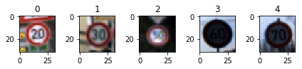

```
Clipping input data to the valid range for imshow with RGB data ([0..1] for floats or [0..255] for integers).
```

[figure not shown]

[figure not shown]

```
Clipping input data to the valid range for imshow with RGB data ([0..1] for floats or [0..255] for integers).
Clipping input data to the valid range for imshow with RGB data ([0..1] for floats or [0..255] for integers).
```

[figure not shown]

```
Clipping input data to the valid range for imshow with RGB data ([0..1] for floats or [0..255] for integers).
```

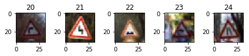

```
Clipping input data to the valid range for imshow with RGB data ([0..1] for floats or [0..255] for integers).
```

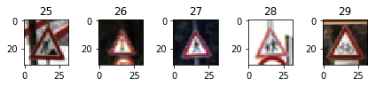

```
Clipping input data to the valid range for imshow with RGB data ([0..1] for floats or [0..255] for integers).
Clipping input data to the valid range for imshow with RGB data ([0..1] for floats or [0..255] for integers).
```

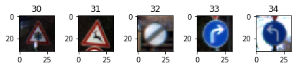

```
Clipping input data to the valid range for imshow with RGB data ([0..1] for floats or [0..255] for integers).
Clipping input data to the valid range for imshow with RGB data ([0..1] for floats or [0..255] for integers).
```

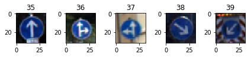

```
Clipping input data to the valid range for imshow with RGB data ([0..1] for floats or [0..255] for integers).
```

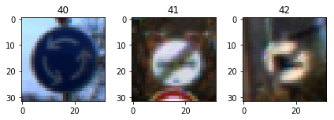

```python
mini_batch_size = 5
images_labels = list(images.keys())
print(len(images))
for start in range(0, len(images_labels), mini_batch_size):
    end = start+mini_batch_size
    end = end if end < len(images_labels) else len(images_labels)
    mini_batch_size = end - start
    fig, axes = plt.subplots(1,mini_batch_size)
    for i, (label, ax) in enumerate(zip(images_labels[start:end], axes)):
        ax.set_title(label)
        ax.imshow(images[label].squeeze())

    plt.tight_layout()
    plt.subplots_adjust(top=0.85)
    plt.show()

images.clear()
```

```python
images_labels = list(all_images.keys())
images_labels = [(key, len(all_images[key])) for key in images_labels]
images_labels = sorted(images_labels, key=lambda x: x[1])
print(images_labels)
```

[output not shown]

```python
from sklearn.utils import shuffle

X_train_norm, y_train_norm = shuffle(X_train_norm, y_train_norm)
```

## Step 2: Design and Test a Model Architecture

Design and implement a deep learning model that learns to recognize traffic signs. Train and test your model on the [German Traffic Sign Dataset](http://benchmark.ini.rub.de/?section=gtsrb&subsection=dataset).

The LeNet-5 implementation shown in the classroom at the end of the CNN lesson is a solid starting point. You'll have to change the number of classes and possibly the preprocessing, but aside from that it's plug and play!

With the LeNet-5 solution from the lecture, you should expect a validation set accuracy of about 0.89. To meet specifications, the validation set accuracy will need to be at least 0.93. It is possible to get an even higher accuracy, but 0.93 is the minimum for a successful project submission.

There are various aspects to consider when thinking about this problem:

- Neural network architecture (is the network over or underfitting?)
- Play around preprocessing techniques (normalization, rgb to grayscale, etc)
- Number of examples per label (some have more than others).
- Generate fake data.

Here is an example of a [published baseline model on this problem](http://yann.lecun.com/exdb/publis/pdf/sermanet-ijcnn-11.pdf). It's not required to be familiar with the approach used in the paper but, it's good practice to try to read papers like these.

## Changes

The LeNet layer contains 5 Layers, hence the name LeNet-5. The first layer is a convolution with a 5x5 filter patch of the same depth. I use relu for our activations and max pooling.

I add two dropouts in the last two layers to prevent overfitting, this felt like overkill and one dropout would have helped without making the learning rate start so slowly.

LeNet is broken down as follows:

### Model Architecture

```python
import tensorflow as tf
from tensorflow.contrib.layers import flatten
```

[output not shown]

```python
def LeNet(x):
    # Hyperparameters
    mu = 0
    sigma = 0.1

    # SOLUTION: Layer 1: Convolutional. Input = 32x32x1. Output = 28x28x6.
    conv1_W = tf.Variable(tf.truncated_normal(shape=(5, 5, 3, 6), mean = mu, stddev = sigma))
    conv1_b = tf.Variable(tf.zeros(6))
    conv1   = tf.nn.conv2d(x, conv1_W, strides=[1, 1, 1, 1], padding='VALID') + conv1_b

    # SOLUTION: Activation.
    conv1 = tf.nn.relu(conv1)

    # SOLUTION: Pooling. Input = 28x28x6. Output = 14x14x6.
    conv1 = tf.nn.max_pool(conv1, ksize=[1, 2, 2, 1], strides=[1, 2, 2, 1], padding='VALID')

    # SOLUTION: Layer 2: Convolutional. Output = 10x10x16.
    conv2_W = tf.Variable(tf.truncated_normal(shape=(5, 5, 6, 16), mean = mu, stddev = sigma))
    conv2_b = tf.Variable(tf.zeros(16))
    conv2   = tf.nn.conv2d(conv1, conv2_W, strides=[1, 1, 1, 1], padding='VALID') + conv2_b

    # SOLUTION: Activation.
    conv2 = tf.nn.relu(conv2)

    # SOLUTION: Pooling. Input = 10x10x16. Output = 5x5x16.
    conv2 = tf.nn.max_pool(conv2, ksize=[1, 2, 2, 1], strides=[1, 2, 2, 1], padding='VALID')

    # SOLUTION: Flatten. Input = 5x5x16. Output = 400.
    fc0   = flatten(conv2)

    # SOLUTION: Layer 3: Fully Connected. Input = 400. Output = 120.
    fc1_W = tf.Variable(tf.truncated_normal(shape=(400, 120), mean = mu, stddev = sigma))
    fc1_b = tf.Variable(tf.zeros(120))
    fc1   = tf.matmul(fc0, fc1_W) + fc1_b

    # SOLUTION: Activation and dropout.
    fc1    = tf.nn.relu(fc1)
    fc1  = tf.nn.dropout(fc1, keep_prob)

    # SOLUTION: Layer 4: Fully Connected. Input = 120. Output = 84.
    fc2_W  = tf.Variable(tf.truncated_normal(shape=(120, 84), mean = mu, stddev = sigma))
    fc2_b  = tf.Variable(tf.zeros(84))
    fc2    = tf.matmul(fc1, fc2_W) + fc2_b

    # SOLUTION: Activation and dropout
    fc2    = tf.nn.relu(fc2)
    fc2    = tf.nn.dropout(fc2, keep_prob)

    # SOLUTION: Layer 5: Fully Connected. Input = 84. Output = 43.
    fc3_W  = tf.Variable(tf.truncated_normal(shape=(84, 43), mean = mu, stddev = sigma))
    fc3_b  = tf.Variable(tf.zeros(43))
    logits = tf.matmul(fc2, fc3_W) + fc3_b

    return logits
```

### Train, Validate and Test the Model

A validation set can be used to assess how well the model is performing. A low accuracy on the training and validation sets imply underfitting. A high accuracy on the training set but low accuracy on the validation set implies overfitting.

```python
x = tf.placeholder(tf.float32, (None, 32, 32, 3))
y = tf.placeholder(tf.int32, (None))
keep_prob = tf.placeholder(tf.float32)
one_hot_y = tf.one_hot(y, 43)

rate = 0.001
EPOCHS = 50
BATCH_SIZE = 28

logits = LeNet(x)
cross_entropy = tf.nn.softmax_cross_entropy_with_logits(logits = logits, labels = one_hot_y)
loss_operation = tf.reduce_mean(cross_entropy)
optimizer = tf.train.AdamOptimizer(learning_rate = rate)
training_operation = optimizer.minimize(loss_operation)

correct_prediction = tf.equal(tf.argmax(logits, 1), tf.argmax(one_hot_y, 1))
accuracy_operation = tf.reduce_mean(tf.cast(correct_prediction, tf.float32))


top_k_val, top_k_idx = tf.nn.top_k(tf.nn.softmax(logits), 5)

saver = tf.train.Saver()

def evaluate(X_data, y_data):
    num_examples = len(X_data)
    total_accuracy = 0
    sess = tf.get_default_session()
    for offset in range(0, num_examples, BATCH_SIZE):
        batch_x, batch_y = X_data[offset:offset+BATCH_SIZE], y_data[offset:offset+BATCH_SIZE]
        accuracy = sess.run(accuracy_operation, feed_dict={x: batch_x, y: batch_y, keep_prob: 1.0})
        total_accuracy += (accuracy * len(batch_x))
    return total_accuracy / num_examples
```

[output not shown]

### Train the model & Save model

Calculate and report the accuracy on the training and validation set. Once a final model architecture is selected, the accuracy on the test set will be calculated and reported as well.

```python
with tf.Session() as sess:
    sess.run(tf.global_variables_initializer())
    num_examples = len(X_train)

    print("Training...")
    print()
    for i in range(EPOCHS):
        X_train, y_train = shuffle(X_train_norm, y_train_norm)
        for offset in range(0, num_examples, BATCH_SIZE):
            end = offset + BATCH_SIZE
            batch_x, batch_y = X_train[offset:end], y_train[offset:end]
            sess.run(training_operation, feed_dict={x: batch_x, y: batch_y, keep_prob: 0.5})

        validation_accuracy = evaluate(X_validate, y_validate)
        if i%10 == 0:
            print("EPOCH {} ...".format(i+1))
            print("Validation Accuracy = {:.3f}".format(validation_accuracy))
            print()
    saver.save(sess, '/home/pmh/Udacity/CarND-Traffic-Sign-Classifier-Project/model')
    print("Model saved")
```

```
Training...

EPOCH 1 ...
Validation Accuracy = 0.783

EPOCH 11 ...
Validation Accuracy = 0.975

EPOCH 21 ...
Validation Accuracy = 0.978

EPOCH 31 ...
Validation Accuracy = 0.975

EPOCH 41 ...
Validation Accuracy = 0.981

Model saved
```

### Test the model

```python
def test():
    with tf.Session() as sess:
        saver.restore(sess, tf.train.latest_checkpoint('.'))

        test_accuracy = evaluate(X_test, y_test)
        print("Test Accuracy = {:.3f}".format(test_accuracy))
```

```python
test()
```

```
INFO:tensorflow:Restoring parameters from /home/pmh/Udacity/CarND-Traffic-Sign-Classifier-Project/model
Test Accuracy = 0.927
```

### Test a Model on New Images

Take several pictures of traffic signs that I found on the web (at least five), and run them through the classifier on my computer to produce example results. The result shown that classifier might not recognize some local signs.

signnames.csv is useful as it contains mappings from the class id (integer) to the actual sign name.

```python
### Load the images and plot them
### convert images to correct shape and grayscale
### predict and print prediction
import os
import tensorflow as tf

dir = 'traffic-Sign_MySample/'

local_files = os.listdir(dir)

labels = [i.partition("-")[0] for i in local_files]
filenames = [dir + '/' + f for f in local_files]

print("labels:{}".format(labels))
print("filenames:{}".format(filenames))
```

[output not shown]

[figure not shown]

```python
import numpy as np
imgs = np.zeros((len(filenames),32,32,3))
labels = [26,5,29,9,14,18,12,31,13,11,17,27,25]
labels = np.array(labels).astype(np.int32)
OriImages = []
from scipy import misc

fig = plt.figure()
for i in range(0,len(filenames)):
    img = cv2.imread('./'+filenames[i])
    img = cv2.cvtColor(img,cv2.COLOR_BGR2RGB)
    OriImages.append(img)
    fig.set_size_inches(13, 15)
    plt.subplot(4,4,i+1)
    plt.title(str(labels[i]))
    plt.imshow(img)
    img  = cv2.resize(img, (32, 32))

    imgs[i] = img
    imgs = imgs.astype(np.float32)
```

```python
with tf.Session() as sess:
    saver.restore(sess, '/home/pmh/Udacity/CarND-Traffic-Sign-Classifier-Project/model')
#     saver.restore(sess, tf.train.latest_checkpoint('.'))

    # test_accuracy = evaluate(X_test, y_test)
    # print("Test Accuracy = {:.3f}".format(test_accuracy))
    private_images_accuracy = evaluate(imgs, labels)
    print("My Images Accuracy = {:.3f}".format(private_images_accuracy))
```

```
INFO:tensorflow:Restoring parameters from /home/pmh/Udacity/CarND-Traffic-Sign-Classifier-Project/model
My Images Accuracy = 0.615
```

### Output Top 5 Softmax Probabilities For Each Image Found on the Web

For each of the new images, print out the model's softmax probabilities to show the certainty of the model's predictions (limit the output to the top 5 probabilities for each image).

```python
# Load signnames.csv to map label number to sign string
label_map = {}
with open('signnames.csv', 'r') as f:
    first_line = True
    for line in f:
        # Ignore first line
        if first_line:
            first_line = False
            continue

        # Populate label_map
        label_int, label_string = line.split(',')
        label_int = int(label_int)
        label_map[label_int] = label_string
```

```python
def display_pred_certainty(image, top_k_val, top_k_idx):
    # Show the image for reference
    fig.set_size_inches(13, 15)
    plt.imshow(image)
    plt.show()
#     print(top_k_idx)
    # Convert top k indices into strings
    i = 0
    for idx in top_k_idx:
        top_k_pred = label_map[idx]
        print(idx)
        print('%s: %.7f%%' % (top_k_pred.replace('\n', ''), top_k_val[i] * 100))
        i += 1
```

```python
def evaluate_top_k(X_data):
    num_examples = len(X_data)
    sess = tf.get_default_session()
    for offset in range(0, num_examples, BATCH_SIZE):
        batch_x = X_data[offset:offset+BATCH_SIZE]
        top_k_vals, top_k_idxs = sess.run([top_k_val, top_k_idx], feed_dict={x: batch_x, keep_prob: 1.0})
    return top_k_vals, top_k_idxs
```

```python
with tf.Session() as sess:
    saver.restore(sess, '/home/pmh/Udacity/CarND-Traffic-Sign-Classifier-Project/model')
    top_k_vals, top_k_idxs = evaluate_top_k(imgs)
    print('top_k_vals:',top_k_vals)
    print('top_k_idxs:',top_k_idxs)
```

```
INFO:tensorflow:Restoring parameters from /home/pmh/Udacity/CarND-Traffic-Sign-Classifier-Project/model
top_k_vals: [[1.0000000e+00 0.0000000e+00 0.0000000e+00 0.0000000e+00 0.0000000e+00]
 [1.0000000e+00 1.1212886e-16 0.0000000e+00 0.0000000e+00 0.0000000e+00]
 [1.0000000e+00 0.0000000e+00 0.0000000e+00 0.0000000e+00 0.0000000e+00]
 [1.0000000e+00 0.0000000e+00 0.0000000e+00 0.0000000e+00 0.0000000e+00]
 [1.0000000e+00 0.0000000e+00 0.0000000e+00 0.0000000e+00 0.0000000e+00]
 [1.0000000e+00 0.0000000e+00 0.0000000e+00 0.0000000e+00 0.0000000e+00]
 [1.0000000e+00 0.0000000e+00 0.0000000e+00 0.0000000e+00 0.0000000e+00]
 [1.0000000e+00 0.0000000e+00 0.0000000e+00 0.0000000e+00 0.0000000e+00]
 [1.0000000e+00 0.0000000e+00 0.0000000e+00 0.0000000e+00 0.0000000e+00]
 [1.0000000e+00 0.0000000e+00 0.0000000e+00 0.0000000e+00 0.0000000e+00]
 [1.0000000e+00 0.0000000e+00 0.0000000e+00 0.0000000e+00 0.0000000e+00]
 [1.0000000e+00 0.0000000e+00 0.0000000e+00 0.0000000e+00 0.0000000e+00]
 [1.0000000e+00 0.0000000e+00 0.0000000e+00 0.0000000e+00 0.0000000e+00]]
top_k_idxs: [[26  0  1  2  3]
 [ 4 13  0  1  2]
 [29  0  1  2  3]
 [23  0  1  2  3]
 [14  0  1  2  3]
 [14  0  1  2  3]
 [12  0  1  2  3]
 [11  0  1  2  3]
 [13  0  1  2  3]
 [11  0  1  2  3]
 [17  0  1  2  3]
 [ 6  0  1  2  3]
 [25  0  1  2  3]]
```

```
Top 5 predictions for the following image (prediction: probability)
```

[figure not shown]

```
26
Traffic signals: 100.0000000%
0
Speed limit (20km/h): 0.0000000%
1
Speed limit (30km/h): 0.0000000%
2
Speed limit (50km/h): 0.0000000%
3
Speed limit (60km/h): 0.0000000%
Top 5 predictions for the following image (prediction: probability)
```

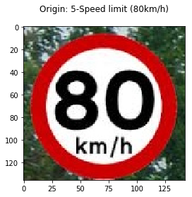

```
4
Speed limit (70km/h): 100.0000000%
13
Yield: 0.0000000%
0
Speed limit (20km/h): 0.0000000%
1
Speed limit (30km/h): 0.0000000%
2
Speed limit (50km/h): 0.0000000%
Top 5 predictions for the following image (prediction: probability)
```

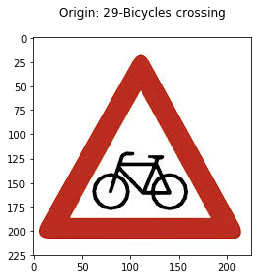

```
29
Bicycles crossing: 100.0000000%
0
Speed limit (20km/h): 0.0000000%
1
Speed limit (30km/h): 0.0000000%
2
Speed limit (50km/h): 0.0000000%
3
Speed limit (60km/h): 0.0000000%
Top 5 predictions for the following image (prediction: probability)
```

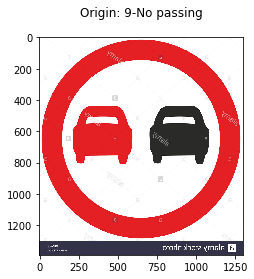

```
23
Slippery road: 100.0000000%
0
Speed limit (20km/h): 0.0000000%
1
Speed limit (30km/h): 0.0000000%
2
Speed limit (50km/h): 0.0000000%
3
Speed limit (60km/h): 0.0000000%
Top 5 predictions for the following image (prediction: probability)
```

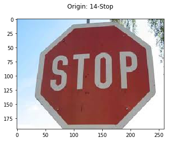

```
14
Stop: 100.0000000%
0
Speed limit (20km/h): 0.0000000%
1
Speed limit (30km/h): 0.0000000%
2
Speed limit (50km/h): 0.0000000%
3
Speed limit (60km/h): 0.0000000%
Top 5 predictions for the following image (prediction: probability)
```

[figure not shown]

```
14
Stop: 100.0000000%
0
Speed limit (20km/h): 0.0000000%
1
Speed limit (30km/h): 0.0000000%
2
Speed limit (50km/h): 0.0000000%
3
Speed limit (60km/h): 0.0000000%
Top 5 predictions for the following image (prediction: probability)
```

[figure not shown]

```
12
Priority road: 100.0000000%
0
Speed limit (20km/h): 0.0000000%
1
Speed limit (30km/h): 0.0000000%
2
Speed limit (50km/h): 0.0000000%
3
Speed limit (60km/h): 0.0000000%
Top 5 predictions for the following image (prediction: probability)
```

[figure not shown]

```
11
Right-of-way at the next intersection: 100.0000000%
0
Speed limit (20km/h): 0.0000000%
1
Speed limit (30km/h): 0.0000000%
2
Speed limit (50km/h): 0.0000000%
3
Speed limit (60km/h): 0.0000000%
Top 5 predictions for the following image (prediction: probability)
```

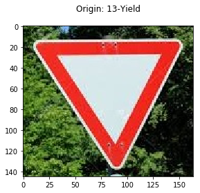

```
13
Yield: 100.0000000%
0
Speed limit (20km/h): 0.0000000%
1
Speed limit (30km/h): 0.0000000%
2
Speed limit (50km/h): 0.0000000%
3
Speed limit (60km/h): 0.0000000%
Top 5 predictions for the following image (prediction: probability)
```

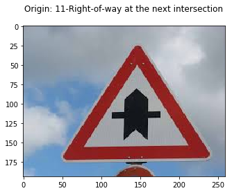

```
11
Right-of-way at the next intersection: 100.0000000%
0
Speed limit (20km/h): 0.0000000%
1
Speed limit (30km/h): 0.0000000%
2
Speed limit (50km/h): 0.0000000%
3
Speed limit (60km/h): 0.0000000%
Top 5 predictions for the following image (prediction: probability)
```

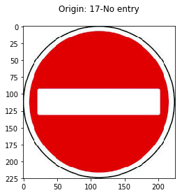

```
17
No entry: 100.0000000%
0
Speed limit (20km/h): 0.0000000%
1
Speed limit (30km/h): 0.0000000%
2
Speed limit (50km/h): 0.0000000%
3
Speed limit (60km/h): 0.0000000%
Top 5 predictions for the following image (prediction: probability)
```

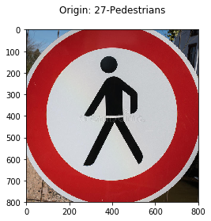

```
6
End of speed limit (80km/h): 100.0000000%
0
Speed limit (20km/h): 0.0000000%
1
Speed limit (30km/h): 0.0000000%
2
Speed limit (50km/h): 0.0000000%
3
Speed limit (60km/h): 0.0000000%
Top 5 predictions for the following image (prediction: probability)
```

[1 more figures not shown]

```
25
Road work: 100.0000000%
0
Speed limit (20km/h): 0.0000000%
1
Speed limit (30km/h): 0.0000000%
2
Speed limit (50km/h): 0.0000000%
3
Speed limit (60km/h): 0.0000000%
```

```python
# plt.figure()
for i, image in enumerate(OriImages):
#     plt.subplot(4,5,i+1)
    plt.figure()
    print('Top 5 predictions for the following image (prediction: probability)')
    plt.title('Origin: ' + str(labels[i])+'-'+label_map[labels[i]])
    display_pred_certainty(image, top_k_vals[i], top_k_idxs[i])

# plt.tight_layout()
# plt.show()
```